# (The Prosper Loan Data Exploration)

## Investigation Overview

> This is a finanacial dataset related to the loan, lenders, borrowers, interest rates, monthly payments, incomes, etc. This dataset is from the Propsper Marketplace Inc., a San Francisco California based company specializing in loan at low interest rates to the borrowers. The dataset contains 113937 entries with 81 variables. The variables included the borrower's location, financial, credit records, the evaluation measurement made by the Prosper platform, and the investor side's information. In the next few sections, I will clean up the data and explore the loan data through applying univariate, bivariate, and multivariate graphs and summaries. Specifically, I explored the dataset to address the concerns listed below.
> 1. What are the characteristics of the borrowers on the Prosper platform.
> 2. What are the factors may help the borrowers to obtain the money.
> 3. What are the factors that play critical roles in determining the borrower rate.
> 4. How the Prosper platform evaluate and manage the risk for the investors.
> 5. The pattern of the investors' preference in choosing the borrowers.

## Dataset Overview

> The dataset contains 113,937 loans with 81 variables. Each loan record contains the loan amount, borrower rate (interest rate), current loan status, borrower's employment status, borrower income, and borrower credit history.

> There are some interesting insights have been revealed from this exploration.

```python
# import all packages and set plots to be embedded inline
import numpy as np
import pandas as pd
import matplotlib.pyplot as plt
import seaborn as sb

%matplotlib inline

# suppress warnings from final output
import warnings
warnings.simplefilter("ignore")
```

```python
# load in the dataset into a pandas dataframe
loan = pd.read_csv('prosperLoanData.csv')
```

> Note that the above cells have been set as "Skip"-type slides. That means that when the notebook is rendered as http slides, those cells won't show up.

> **First, I am curious about the borrowers background.** Stepping into debt is a significant decision to make for a person. I want to know more about the borrowers' background information like their living locations and their financial status.

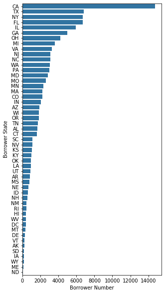

```python
# plotting the EmploymentStatus
color_base = sb.color_palette()[0]
plt.figure(figsize = [5, 10])
sb.countplot(data = loan, y = 'BorrowerState', color = color_base,
             order = loan['BorrowerState'].value_counts().index)

plt.xlabel('Borrower Number')
plt.ylabel('Borrower State')
```

> The visualization above shows far more borrowers came from California compare to other states. The top two to five states of the borrowers using Prosper are Texax, New York, Florida, and Illinois. The potential explanations for the borrower location distribution are listed below.
> - Since the Prosper platform is based in California, it is reasonable to have most borrowers using its plaform.
> - The living expense in California is also among the highest in the US.

```python
loan['LoanOriginalAmount'].describe()
```

```
count    113937.00000
mean       8337.01385
std        6245.80058
min        1000.00000
25%        4000.00000
50%        6500.00000
75%       12000.00000
max       35000.00000
Name: LoanOriginalAmount, dtype: float64
```

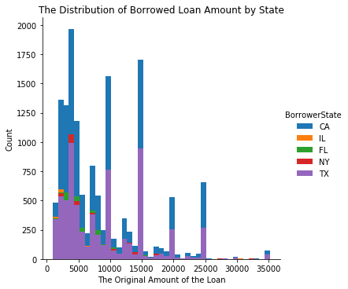

```python
# plot the chart size
plt.figure(figsize = [15, 5])

# set the borrower state range
loan_sub = loan.loc[loan['BorrowerState'].isin(['CA', 'TX', 'NY', 'FL', 'IL'])]

# plotting histogram
binsize = 833.7
bins = np.arange(999, loan_sub['LoanOriginalAmount'].max()+binsize, binsize);
group_order = ['CA', 'FL', 'IL', 'NY', 'TX']

# plot the histogram of the BorrowerRate
g = sb.FacetGrid(data = loan_sub, hue = 'BorrowerState',
                 height = 5)
g.map(plt.hist, 'LoanOriginalAmount', bins = bins, histtype = 'bar')
g.add_legend()

# chart labels
plt.xlabel('The Original Amount of the Loan')
plt.ylabel('Count')
plt.title('The Distribution of Borrowed Loan Amount by State')
```

> - The peak loan amounts are 4k, 10k, 15k, 20k, 25k.
> - Why the borrowers in the above five states prefer to borrow those specific amount of money is an interesting direction for further explore.
> - Note that the highest peak amount is 4k. Why the borrowers chose this much amount of money?

Before we dive into the above questions, let's explore the other aspects of the borrowers' background information first. Let's see what they do for a living and how much they earn.

```python
loan['BorrowerRate'].describe()
```

```
count    113937.000000
mean          0.192764
std           0.074818
min           0.000000
25%           0.134000
50%           0.184000
75%           0.250000
max           0.497500
Name: BorrowerRate, dtype: float64
```

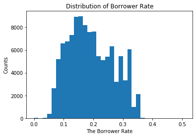

```python
# Plot the BorrowerRate
binsize = 0.015
bins = np.arange(0, loan['BorrowerRate'].max()+binsize, binsize)

# plot the histogram of the BorrowerRate
#plt.figure(figsize = [10, 5])
plt.hist(data = loan, x = 'BorrowerRate', bins = bins)

#plt.xticks =

plt.title('Distribution of Borrower Rate')
plt.xlabel('The Borrower Rate')
plt.ylabel('Counts')
```

> - The mean borrowing rate was 0.192 with median at 0.184 on loan amounts.

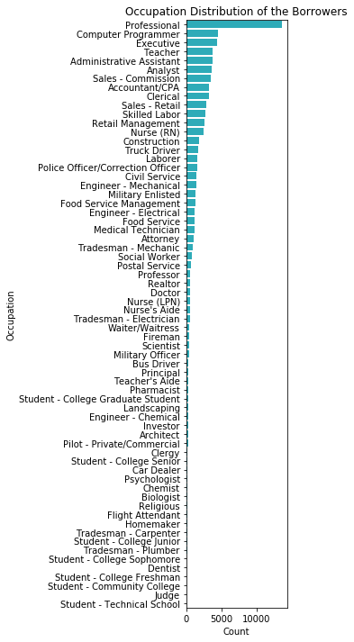

```python
# check the borrowers
# set a big chart
loan1 = loan[loan['Occupation'] != 'Other']
plt.figure(figsize = [2, 12])
color_2 = sb.color_palette()[9]
sb.countplot(data = loan1, y = 'Occupation', color = color_2,
             order = loan1['Occupation'].value_counts().index)

plt.title('Occupation Distribution of the Borrowers');
plt.xlabel('Count');
plt.ylabel('Occupation');
```

> Most borrowers on Prosper self-identified as Professional, Computer Programmer, Executive, Teacher, Aministrative Assistant, and Analyst. **Note:** The borrowers who self-identified as 'Other' in the occupation column have been excluded from the this analysis. **Insights**
> - The top five occupation workers are usually regarded as well educated, creditworthy, and have relatively high income.
> - The large number of executives also borrow money from the Prosper platform is very surprising.

Then, what is the borrower's employment status and how much do they earn?

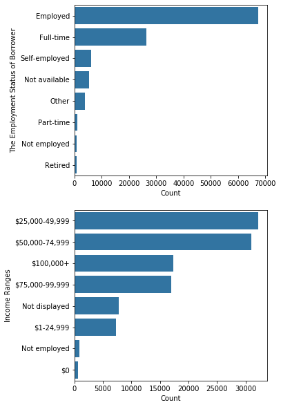

```python
# plot a big chart
plt.figure(figsize = [5, 10])

# left chart, the EmploymentStatus
plt.subplot(2, 1, 1)
sb.countplot(data = loan, y = 'EmploymentStatus', color = color_base,
             order = loan['EmploymentStatus'].value_counts().index)
# axis labels
plt.xlabel('Count')
plt.ylabel('The Employment Status of Borrower')

# right chart, the Income Range counts
plt.subplot(2, 1, 2)
sb.countplot(data = loan, y = 'IncomeRange', color = color_base,
             order = loan['IncomeRange'].value_counts().index)

plt.xlabel('Count')
plt.ylabel('Income Ranges')
```

> - Most the borrowers are identified as **employed** (67322 counts), and 26355 have **full-time** works, followed by 6134 **self-employed** borrowers.
> - The top three income ranges of the borrowers are USD 25,000-USD 49,999 followed by USD 50,000-USD 74,999 and USD 100,000+.

```python
loan['CreditScoreRangeUpper'].describe()
```

```
count    113346.000000
mean        704.567731
std          66.458275
min          19.000000
25%         679.000000
50%         699.000000
75%         739.000000
max         899.000000
Name: CreditScoreRangeUpper, dtype: float64
```

```python
print(np.log10(5000))
print(np.log10(10000))
print(np.log10(15000))
```

```
3.6989700043360187
4.0
4.176091259055681
```

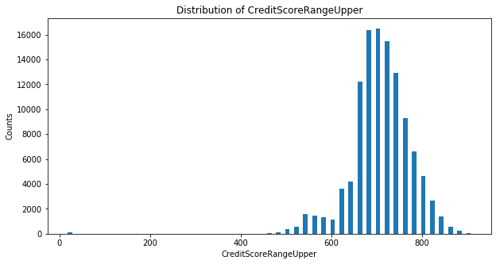

```python
# Plot the CreditScoreRangeUpper
binsize = 10
bins = np.arange(18, loan['CreditScoreRangeUpper'].max()+binsize, binsize)

# plot the histogram of the BorrowerRate
plt.figure(figsize = [10, 5])
plt.hist(data = loan, x = 'CreditScoreRangeUpper', bins = bins)

plt.title('Distribution of CreditScoreRangeUpper')
plt.xlabel('CreditScoreRangeUpper')
plt.ylabel('Counts')
```

#### What was the loan used for?

> The dataset also provided the purpose of the loan as below. 0 - Not Available, 1 - Debt Consolidation, 2 - Home Improvement, 3 - Business, 4 - Personal Loan, 5 - Student Use, 6 - Auto, 7- Other, 8 - Baby&Adoption, 9 - Boat, 10 - Cosmetic Procedure, 11 - Engagement Ring, 12 - Green Loans, 13 - Household Expenses, 14 - Large Purchases, 15 - Medical/Dental, 16 - Motorcycle, 17 - RV, 18 - Taxes, 19 - Vacation, 20 - Wedding Loans

Let's take a closer look at the top ten reasons for borrow the loan.

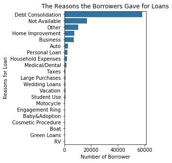

```python
plt.figure(figsize = [3, 5])

# set the borrower state range
sb.countplot(data = loan, y = 'ListingCategory (numeric)', color = color_base,
             order = loan['ListingCategory (numeric)'].value_counts().index)
ytick_locs = [0, 1, 2, 3, 4, 5, 6, 7, 8, 9, 10, 11, 12, 13, 14, 15, 16, 17, 18, 19, 20]
ytick_sbl = ['Debt Consolidation', 'Not Available', 'Other', 'Home Improvement', 'Business', 'Auto', 'Personal Loan',
             'Household Expenses', 'Medical/Dental', 'Taxes', 'Large Purchases', 'Wedding Loans',
             'Vacation', 'Student Use', 'Motocycle', 'Engagement Ring', 'Baby&Adoption',
             'Cosmetic Procedure', 'Boat', 'Green Loans', 'RV']
plt.yticks(ytick_locs, ytick_sbl)

plt.title('The Reasons the Borrowers Gave for Loans')
plt.xlabel('Number of Borrower')
plt.ylabel('Reasons for Loan')
```

> - The top reason for borrowing was debt consolidation, followed by home improvement, business, auto and personal loan sequentially.

So far we have explored some characteristics of the borrowers in the dataset, now I want to investigate how the Prosper system evaluate the borrower based on the obtained information and whether the Prosper system can help to develop the platform

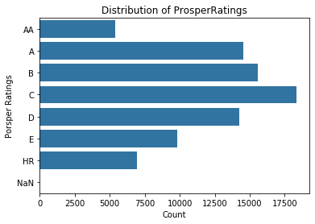

```python
# set the order of the levels in ProsperRatings
prosprtngs = ['AA', 'A', 'B', 'C', 'D', 'E', 'HR', 'NaN']
rtngs = pd.api.types.CategoricalDtype(ordered = True,
                                      categories = prosprtngs)
loan['ProsperRating (Alpha)'] = loan['ProsperRating (Alpha)'].astype(rtngs)

# the ProsperRatings distribution
sb.countplot(data = loan, y = 'ProsperRating (Alpha)', color = color_base)

plt.xlabel('Count')
plt.ylabel('Porsper Ratings')
plt.title('Distribution of ProsperRatings')
```

> - The Prosper Ratings Alpha range from AA to HR indicate the risk from low to high.
> - The borrowers with prosper ranting C were the most.

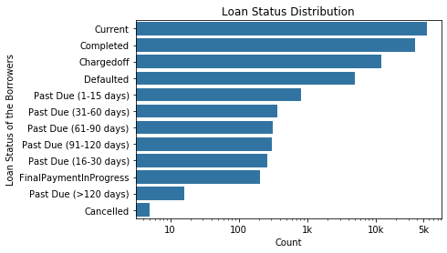

```python
# the bar chart of the listing category variables
sb.countplot(data = loan, y = 'LoanStatus', color = color_base,
             order = loan['LoanStatus'].value_counts().index)

plt.title('Loan Status Distribution');
plt.xlabel('Count');
plt.ylabel('Loan Status of the Borrowers');
plt.xscale('log')
plt.xticks([10, 100, 1000, 10000, 50000],
           ['10', '100', '1k', '10k', '5k']);
```

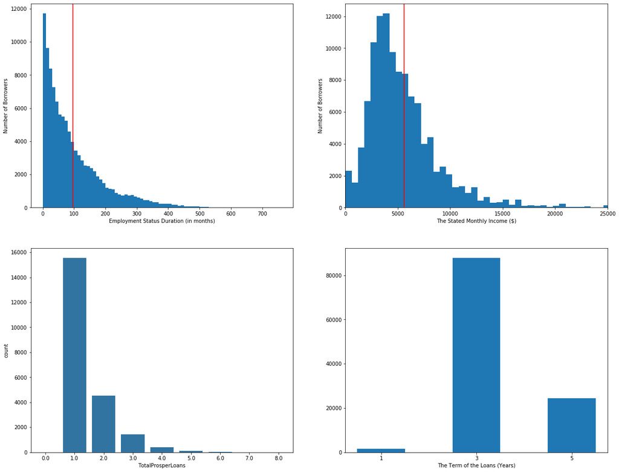

```python
# set a big chart
plt.figure(figsize = [20, 16])
color_base = sb.color_palette()[0]

# the top left one, EmploymentStatusDuration
plt.subplot(2, 2, 1)
binsize = 10
bins = np.arange(0, 755+binsize, binsize);
plt.hist(data = loan, x = 'EmploymentStatusDuration', bins = bins, color = color_base);
plt.xlabel('Employment Status Duration (in months)')
plt.ylabel('Number of Borrowers')
plt.axvline(x = 96, color = 'r') # indicate the mean value

# the top right chart, StatedMonthlyIncome
plt.subplot(2, 2, 2)
binsize = 600
bins = np.arange(0, 1750003+binsize, binsize)
plt.hist(data = loan, x = 'StatedMonthlyIncome', bins = bins, color = color_base)
plt.xlim(0, 25000)
plt.xlabel('The Stated Monthly Income ($)')
plt.ylabel('Number of Borrowers')
plt.axvline(x = 5.608026e+03, color = 'r') # the location of the red line indicate the mean value

# the bottom left chart, TotalProsperLoans
plt.subplot(2, 2, 3)
sb.countplot(data = loan, x = 'TotalProsperLoans', color = color_base)

# the bottom right chart, LoanReasons
plt.subplot(2, 2, 4)
# start with a standard-scaled plot
binsize = 12
bins = np.arange(4, 76, 12)

plt.hist(data = loan, x = 'Term', bins = bins)
plt.xticks([10, 34, 58], [1, 3, 5])
plt.xlabel('The Term of the Loans (Years)')
plt.show()
```

## Univariate Analysis

> Based the previous analysis, the questions below can be partially answered as listed.

### Discuss the distribution(s) of your variable(s) of interest. Were there any unusual points? Did you need to perform any transformations?

> The visualization above shows far more borrowers came from California compare to other states. The top two to five states of the borrowers using Prosper are Texax, New York, Florida, and Illinois. The potential explanations for the borrower location distribution are listed below.
> > - Since the Prosper platform is based in California, it is reasonable to have most borrowers using its plaform.
> > - The living expense in California is also among the highest in the US. To further investigate where the loan money went, I created the plot of the LoanOriginalAmount distribution by the states. The plot shows -The peak loan amounts are 4k, 10k, 15k, 20k, 25k.
> > - Why the borrowers in the above five states prefer to borrow those specific amount of money is an interesting direction for further explore.
> > - Note that the highest peak amount is 4k. Why the borrowers chose this much amount of money?

> There are unusal points like some borrower claimed their income as 0USD. Other than that, there were missing values. So plots were made with subsets of the data excluded those values.

> Most borrowers on Prosper self-identified as Professional, Computer Programmer, Executive, Teacher, Aministrative Assistant, and Analyst. **Note:** The borrowers who self-identified as 'Other' in the occupation column have been excluded from the this analysis. **Insights**
> - The top five occupation workers are usually regarded as well educated, creditworthy, and have relatively high income.
> - The large number of executives also borrow money from the Prosper platform is very surprising.

> Then, what is the borrower's employment status and how much do they earn?
> - Most the borrowers are identified as **employed** (67322 counts), and 26355 have **full-time** works, followed by 6134 **self-employed** borrowers.
> - The top three income ranges of the borrowers are USD 25,000-USD 49,999 followed by USD 50,000-USD 74,999 and USD 100,000+.
> - The top reason for borrowing was debt consolidation, followed by home improvement, business, auto and personal loan sequentially.

### Of the features you investigated, were there any unusual distributions? Did you perform any operations on the data to tidy, adjust, or change the form of the data? If so, why did you do this?

> The LoanOrignalAmount distribution was right skewed. But I did not change the form of the data. I will change the form of the data in the bivariate analysis.

## Bivariate Plots Section

> Before diving into the exploration of bivariate variables in detail, I will create a scatterplot matrix for the numerical factors to get a big picture first.

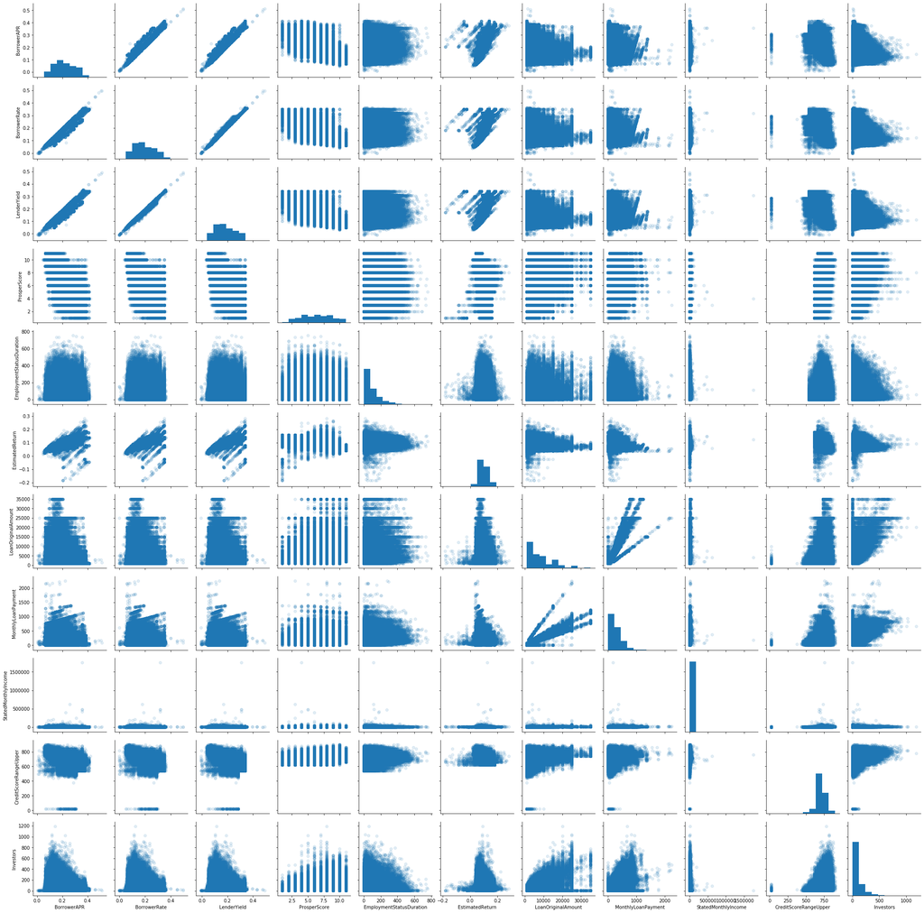

```python
num_vars = ['BorrowerAPR', 'BorrowerRate', 'LenderYield', 'ProsperScore', 'EmploymentStatusDuration',
            'EstimatedReturn', 'LoanOriginalAmount', 'MonthlyLoanPayment', 'StatedMonthlyIncome',
            'CreditScoreRangeUpper', 'Investors']

g = sb.PairGrid(data = loan, vars = num_vars)
g.map_diag(plt.hist)
g.map_offdiag(plt.scatter, alpha = 1/8)
```

**Summary**

- The scatter matrix above provided a big picture of the potential correlationship between each numeric variables involved.
- For the correlated pairs of variables there seem to be some linear relationships.
- However, some relationship are non-linear.
- The messy scatter plots where no obvious relationship can be detected indicate those are uncorrelated variables.

*To get a better understanding of the correlated variables, the variables showed strong correlationship have been replotted below.*

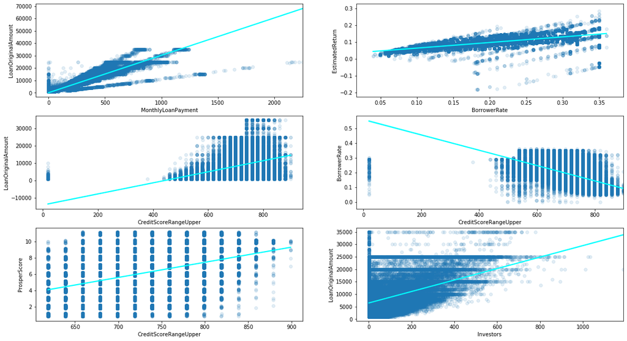

```python
# plot a big chart
plt.figure(figsize = [20, 15])

# MonthlyLoanPayment vs. LoanOriginalAmount
plt.subplot(4, 2, 1)
#sb.set(style = 'white', color_codes = True)
sb.regplot(data = loan, x = 'MonthlyLoanPayment', y = 'LoanOriginalAmount',
           scatter_kws = {'alpha' : 1/8}, line_kws = {'color' : 'cyan'})
plt.xlabel('MonthlyLoanPayment')
plt.ylabel('LoanOriginalAmount')

# BorrowerRate vs. EstimatedReturn
plt.subplot(4, 2, 2)
sb.regplot(data = loan, x = 'BorrowerRate', y = 'EstimatedReturn',
           scatter_kws = {'alpha' : 1/8}, line_kws = {'color' : 'cyan'})
plt.xlabel('BorrowerRate')
plt.ylabel('EstimatedReturn')

# CreditScoreRangeUpper vs. LoanOriginalAmount
plt.subplot(4, 2, 3)
sb.regplot(data = loan, x = 'CreditScoreRangeUpper', y = 'LoanOriginalAmount',
            x_jitter = 0.2, y_jitter = 0.2, scatter_kws = {'alpha' : 1/8},
           line_kws = {'color' : 'cyan'})
plt.xlabel('CreditScoreRangeUpper')
plt.ylabel('LoanOriginalAmount')

# CreditScoreRangeUpper vs. BorrowerRate
plt.subplot(4, 2, 4)
sb.regplot(data = loan, x = 'CreditScoreRangeUpper', y = 'BorrowerRate',
           scatter_kws = {'alpha' : 1/8}, line_kws = {'color' : 'cyan'})
plt.xlabel('CreditScoreRangeUpper')
plt.ylabel('BorrowerRate')

# CreditScoreRangeUpper vs. ProsperScore
plt.subplot(4, 2, 5)
sb.regplot(data = loan, x = 'CreditScoreRangeUpper', y = 'ProsperScore',
            x_jitter = 0.2, y_jitter = 0.2, scatter_kws = {'alpha' : 1/8},
           line_kws = {'color' : 'cyan'})
plt.xlabel('CreditScoreRangeUpper')
plt.ylabel('ProsperScore')

# LoanOriginalAmount vs. Investors
plt.subplot(4, 2, 6)
sb.regplot(data = loan, x = 'Investors', y = 'LoanOriginalAmount',
           scatter_kws = {'alpha' : 1/8}, line_kws = {'color' : 'cyan'})
plt.xlabel('Investors')
plt.ylabel('LoanOriginalAmount')
```

### Removing Unusual Data and Outliers

Because the ProsperRating records did not exist prior to July 2009, it shows as missing data in the earlier records. Prior to 2009, the CreditGrade was used as the evaluation system by Prosper. Since we have more ProsperRating over CrediGrade records, the rows with the CrediGrade records will be excluded from this analysis. The additional rows with the conditions below will also be excluded

> - The borrower's income information is missing
> - The borrower rate is above 0.35
> - Missing employment status information
> - Credit socre lower than 400

```python
loan.shape
```

```
(113937, 81)
```

```python
loan3 = loan.dropna(subset=['IncomeRange', 'EmploymentStatus',
                           'CreditScoreRangeLower', 'CreditScoreRangeUpper'])
loan3.shape
```

```
(111680, 81)
```

```python
# set the order of the IncomeRanges
incomnrngs = ['$1-24,999', '$25,000-49,999', '$50,000-74,999',
             '$75,000-99,999', '$100,000+']
incomns = pd.api.types.CategoricalDtype(ordered = True,
                                        categories = incomnrngs)
loan3['IncomeRange'] = loan3['IncomeRange'].astype(incomns)
```

```python
print(loan3['CreditScoreRangeUpper'].describe())
print(loan3['BorrowerRate'].describe())
print(loan3['DebtToIncomeRatio'].describe())
```

```
count    111680.000000
mean        705.880014
std          64.379575
min          19.000000
25%         679.000000
50%         699.000000
75%         739.000000
max         899.000000
Name: CreditScoreRangeUpper, dtype: float64
count    111680.000000
mean          0.192910
std           0.074878
min           0.000000
25%           0.134000
50%           0.184000
75%           0.250600
max           0.360000
Name: BorrowerRate, dtype: float64
count    103155.000000
mean          0.277877
std           0.551836
min           0.000000
25%           0.150000
50%           0.220000
75%           0.320000
max          10.010000
Name: DebtToIncomeRatio, dtype: float64
```

```python
#loan4 = loan3.dropna(subset=['DebtToIncomeRatio'])
#loan4.shape
```

```python
#loan5 = loan4[loan4['CreditGrade'].isnull()]
#loan5.shape
```

```python
loan4 = loan3.dropna(subset=['ProsperRating (Alpha)'])
loan4.shape
```

```
(84853, 81)
```

```python
loan4 = loan4[loan4['ProsperRating (Alpha)'].notnull()]
loan4.shape
loan4['ProsperRating (Alpha)'].unique()
```

```
[A, D, B, E, C, AA, HR]
Categories (7, object): [AA < A < B < C < D < E < HR]
```

```python
loan4 = loan4[loan4['IncomeRange'].notnull()]
loan4['IncomeRange'].unique()
```

```
[$50,000-74,999, $25,000-49,999, $100,000+, $75,000-99,999, $1-24,999]
Categories (5, object): [$1-24,999 < $25,000-49,999 < $50,000-74,999 < $75,000-99,999 < $100,000+]
```

```python
loan5 = loan4[loan4['CreditScoreRangeUpper'] > 400]
loan5 = loan5[loan5['BorrowerRate'] < 0.35]
loan5.shape
```

```
(83363, 81)
```

```python
loan6 = loan5[loan5['EmploymentStatus'] != 'Not available']
loan6 = loan6[loan6['EmploymentStatus'].notnull()]
loan6.shape
```

```
(83363, 81)
```

```python
loan6['ProsperRating (Alpha)'].unique()
```

```
[A, D, B, E, C, AA, HR]
Categories (7, object): [AA < A < B < C < D < E < HR]
```

### Let's take a look at the variables that may play critical roles in determining the borrower rate.

*I will use histogram to plot the borrower rate, with different colors to differentiate the sub-variables in the Prosper Ratings, Income Ranges, Employment Status, and whether a House Owner to identifity the critical variables.

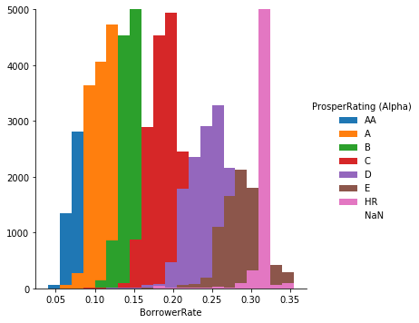

```python
# plotting histogram
binsize = 0.015
bins = np.arange(0.04, loan6['BorrowerRate'].max()+binsize, binsize);
#group_order = ['AA', 'A', 'B', 'C', 'D', 'E', 'HR']

# plot the histogram of the BorrowerRate
g = sb.FacetGrid(data = loan6, hue = 'ProsperRating (Alpha)',
                 height = 5)
g.map(plt.hist, 'BorrowerRate', bins = bins, histtype = 'bar', stacked = True)
g.add_legend()
g.set(ylim = (0, 5000))
```

- The Borrower Rate histogram is highly correlated with the Prosper Rating. The decreasing prosper rate (which indicates the increasing risks) is correlated with an increasing borrower rate.

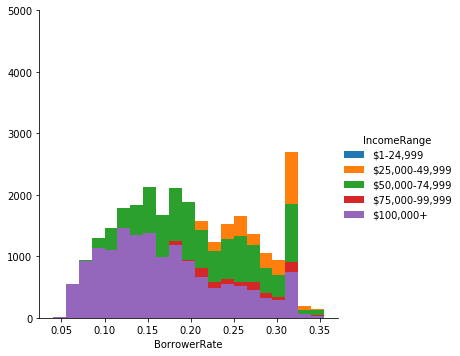

```python
# plotting histogram
binsize = 0.015
bins = np.arange(0.04, loan6['BorrowerRate'].max()+binsize, binsize);
#group_order = ['AA', 'A', 'B', 'C', 'D', 'E', 'HR']

# plot the histogram of the BorrowerRate
g = sb.FacetGrid(data = loan6, hue = 'IncomeRange',
                 height = 5)
g.map(plt.hist, 'BorrowerRate', bins = bins, histtype = 'bar', stacked = True)
g.add_legend()
g.set(ylim = (0, 5000))
```

- When colored with the income range, the peaks of the borrowers with higher incomes (USD50,000-74,999 and USD100k+) clearly shift towards left, indicating a lower borrwer rate (between 0.1 and 0.2). Interestingly, the borrowers with lower incomes(USD 2.5k to 4.9k) shift towards the right side, indicateing a higher borrower rate (0.2 to 0.35). There's a peak at 0.32 for most income ranges.

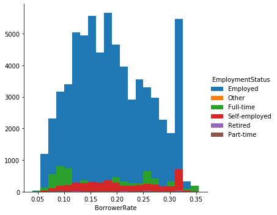

```python
# plotting histogram
binsize = 0.015
bins = np.arange(0.04, loan6['BorrowerRate'].max()+binsize, binsize);
#group_order = ['AA', 'A', 'B', 'C', 'D', 'E', 'HR']

# plot the histogram of the BorrowerRate
g = sb.FacetGrid(data = loan6, hue = 'EmploymentStatus',
                 height = 5)
g.map(plt.hist, 'BorrowerRate', bins = bins, histtype = 'bar')
g.add_legend()
#g.set(ylim = (0, 5000))
```

- The plot also showed most the borrowers are employed.

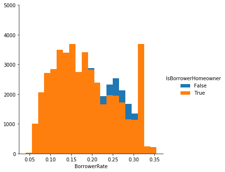

```python
# plotting histogram
binsize = 0.015
bins = np.arange(0.04, loan6['BorrowerRate'].max()+binsize, binsize);
#group_order = ['AA', 'A', 'B', 'C', 'D', 'E', 'HR']

# plot the histogram of the BorrowerRate
g = sb.FacetGrid(data = loan6, hue = 'IsBorrowerHomeowner',
                 height = 5)
g.map(plt.hist, 'BorrowerRate', bins = bins, histtype = 'bar')
g.add_legend()
g.set(ylim = (0, 5000))
```

- Also, owning a home did help to decrease the borrowing rate for the given dataset.

```python
print(loan6['BorrowerRate'].describe())
print(loan6['LoanOriginalAmount'].describe())
```

```
count    83363.000000
mean         0.194005
std          0.073261
min          0.040000
25%          0.135500
50%          0.186400
75%          0.255400
max          0.349900
Name: BorrowerRate, dtype: float64
count    83363.000000
mean      9171.990931
std       6294.028754
min       1000.000000
25%       4000.000000
50%       7500.000000
75%      14000.000000
max      35000.000000
Name: LoanOriginalAmount, dtype: float64
```

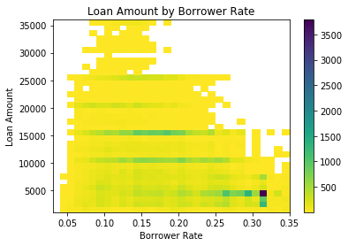

```python
# plot a hist map of BorrowerRate vs. LoanOriginalAmount
bins_x = np.arange(0.03, loan6['BorrowerRate'].max()+0.01, 0.01)
bins_y = np.arange(999, loan6['LoanOriginalAmount'].max()+1000, 1000)

plt.hist2d(data = loan6, x = 'BorrowerRate', y = 'LoanOriginalAmount',
           cmap = 'viridis_r', cmin = 0.5, bins = [bins_x, bins_y])
plt.colorbar()
plt.xlabel('Borrower Rate')
plt.ylabel('Loan Amount')
plt.title('Loan Amount by Borrower Rate')
```

> - The loan amount tend to fall on 4k, 10k, 15k, 20k, and 25k these five peaks.
> - On each specific loan amount peak, the borrower rate has a wide spread.
> - Specifically, at the 4k peak, more counts is obseved at higher borrower rate range (0.25 to 0.32).
> - On 10k, 15k, 20k, and 25k loan amount peaks, the borrower rate mainly aggregate from 0.1 to 0.25.
> - At higher loan amount 20k and 25k, the borrower rate shift towards the left compare to the lower loan amount 10k and 4k.

```python
print(loan6['Investors'].describe())
print(loan6['LoanOriginalAmount'].describe())
```

```
count    83363.000000
mean        68.537984
std         95.788084
min          1.000000
25%          1.000000
50%         31.000000
75%         98.000000
max       1189.000000
Name: Investors, dtype: float64
count    83363.000000
mean      9171.990931
std       6294.028754
min       1000.000000
25%       4000.000000
50%       7500.000000
75%      14000.000000
max      35000.000000
Name: LoanOriginalAmount, dtype: float64
```

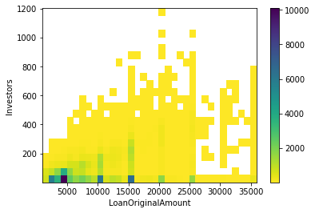

```python
# plot a hist map of Investors vs. StatedMonthlyIncome
bins_y = np.arange(0.99, loan6['Investors'].max()+50, 50)
bins_x = np.arange(999, loan6['LoanOriginalAmount'].max()+1000, 1000)

plt.hist2d(data = loan6, y = 'Investors', x = 'LoanOriginalAmount',
           cmap = 'viridis_r', cmin = 0.5, bins = [bins_x, bins_y])

plt.colorbar()
plt.xlabel('LoanOriginalAmount')
plt.ylabel('Investors')
#plt.title(' by Borrower Rate')
```

```python
loan6['MonthlyLoanPayment'].describe()
```

```
count    83363.000000
mean       294.172076
std        186.908911
min          0.000000
25%        158.870000
50%        255.520000
75%        390.260000
max       2251.510000
Name: MonthlyLoanPayment, dtype: float64
```

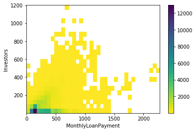

```python
# plot a hist map of Investors vs. StatedMonthlyIncome
bins_y = np.arange(0.99, loan6['Investors'].max()+50, 50)
bins_x = np.arange(0, loan6['MonthlyLoanPayment'].max()+60, 60)

plt.hist2d(data = loan6, y = 'Investors', x = 'MonthlyLoanPayment',
           cmap = 'viridis_r', cmin = 0.5, bins = [bins_x, bins_y])

plt.colorbar()
plt.xlabel('MonthlyLoanPayment')
plt.ylabel('Investors')
#plt.title(' by Borrower Rate')
```

### Check and clean the dataset before further exploration.

```python
# load the dataset again and start from the beginning
loan = pd.read_csv('prosperLoanData.csv')
loan.shape
```

```
(113937, 81)
```

```python
# check the dataset
print(loan['CreditGrade'].unique())
print(loan['IncomeRange'].unique())
print(loan['BorrowerRate'].unique())
print(loan['EmploymentStatus'].unique())
print(loan['CreditScoreRangeUpper'].unique())
print(loan['ProsperRating (Alpha)'].unique())
```

```
['C' nan 'HR' 'AA' 'D' 'B' 'E' 'A' 'NC']
['$25,000-49,999' '$50,000-74,999' 'Not displayed' '$100,000+'
 '$75,000-99,999' '$1-24,999' 'Not employed' '$0']
[0.158  0.092  0.275  ... 0.2037 0.2309 0.0739]
['Self-employed' 'Employed' 'Not available' 'Full-time' 'Other' nan
 'Not employed' 'Part-time' 'Retired']
[659. 699. 499. 819. 759. 719. 839. 779. 679. 639. 739. 539. 799. 619.
 599. 559. 579. 519. 859. 879.  nan 479.  19. 899. 459. 439. 379.]
[nan 'A' 'D' 'B' 'E' 'C' 'AA' 'HR']
```

### Data Wrangling

  > Sort out the order of the values in PropsperRating (Alpha) and IncomeRange columns

```python
loan = loan.dropna(subset=['IncomeRange', 'EmploymentStatus',
                             'CreditScoreRangeLower', 'CreditScoreRangeUpper',
                             'ProsperRating (Alpha)'])
loan.shape
```

```
(84853, 81)
```

```python
# remove the rows with 'CreditGrade' records
loan = loan[loan['CreditGrade'].isnull()]

loan = loan[loan['CreditScoreRangeUpper'] > 400]
loan = loan[loan['BorrowerRate'] < 0.35]

loan.shape
```

```
(84046, 81)
```

Set the order for the ProsperRatings and IncomeRanges

```python
# set the order of the ProsperRatings
prosprtngs = ['AA', 'A', 'B', 'C', 'D', 'E', 'HR']
rtngs = pd.api.types.CategoricalDtype(ordered = True,
                                      categories = prosprtngs)
loan['ProsperRating (Alpha)'] = loan['ProsperRating (Alpha)'].astype(rtngs)
```

```python
# set the order of the IncomeRanges
incomnrngs = ['$1-24,999', '$25,000-49,999', '$50,000-74,999',
             '$75,000-99,999', '$100,000+']
incomns = pd.api.types.CategoricalDtype(ordered = True,
                                        categories = incomnrngs)
loan['IncomeRange'] = loan['IncomeRange'].astype(incomns)
```

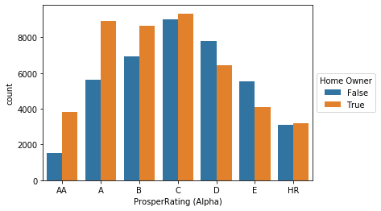

```python
prosprtng_order = ['AA', 'A', 'B', 'C', 'D', 'E', 'HR']
#housownr_order = [True, False]

sb.countplot(data = loan, x = 'ProsperRating (Alpha)',
             hue = 'IsBorrowerHomeowner')

g.add_legend()
plt.legend(['False', 'True'], title = 'Home Owner',
           loc = 6, bbox_to_anchor = (1.0, 0.5))
```

- The plot shows owning a house did help the borrowers to get a better prosper rating scale. But for the borrowers with worse prosper rating scale, owning a house didn't help much.

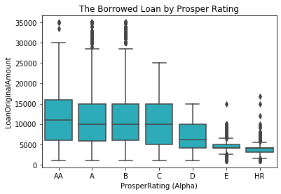

```python
base_color = sb.color_palette()[9]

# the first, ProsperRating vs. LoanOriginalAmount

ax0 = sb.boxplot(data = loan, x = 'ProsperRating (Alpha)',
                 y = 'LoanOriginalAmount', color = base_color)
plt.xlabel('ProsperRating (Alpha)')
plt.ylabel('LoanOriginalAmount')
plt.title('The Borrowed Loan by Prosper Rating')
```

> - The plot shows the borrower has higher prosper rating scales D, E, and HR (high risk) obtain less amount of loan money. The average amount of the loan money for E and HR borrowers is around 4k.
> - Since the borrower with high prosper rating scale indicate a high risk, it is reasonable that these borrowers (D, E, HR) will have more difficulties to borrow larger loan amounts on the Prosper platform.

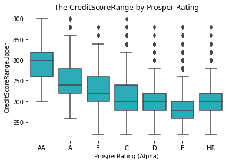

```python
# the second chart, ProsperRating vs. CreditScoreRangUpper

ax1 = sb.boxplot(data = loan, x = 'ProsperRating (Alpha)',
                 y = 'CreditScoreRangeUpper', color = base_color)
plt.xlabel('ProsperRating (Alpha)')
plt.ylabel('CreditScoreRangeUpper')
plt.title('The CreditScoreRange by Prosper Rating')
```

> - The plot shows the ProsperRating system is generally consistent with the CreditScoreRangeUpper system becuase higher PropsperRating scale (low risk) is associate with higher CreditScoreRangeUpper Score.

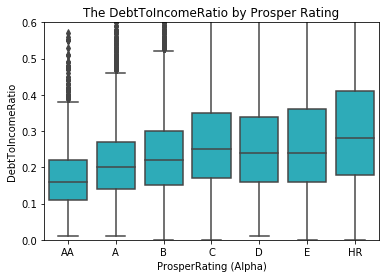

```python
# the third chart, ProsperRating vs. DebtToIncomeRatio

ax2 = sb.boxplot(data = loan, x = 'ProsperRating (Alpha)',
                 y = 'DebtToIncomeRatio', color = base_color)
plt.ylim(0, 0.6)
plt.xlabel('ProsperRating (Alpha)')
plt.ylabel('DebtToIncomeRatio')
plt.title('The DebtToIncomeRatio by Prosper Rating')
```

> - The plot shows the debt to income ratio raises as the prosper rating decreases.

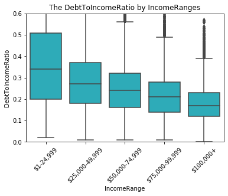

```python
# the forth chart, IncomeRanges vs. DebtToIncomeRatio

ax3 = sb.boxplot(data = loan, x = 'IncomeRange',
                 y = 'DebtToIncomeRatio', color = base_color)
plt.ylim(0, 0.6)
plt.xlabel('IncomeRange')
plt.ylabel('DebtToIncomeRatio')
plt.title('The DebtToIncomeRatio by IncomeRanges')
plt.xticks(rotation = 45)
```

> - The plot shows as the income range increases, the debt to income ratio decreases.

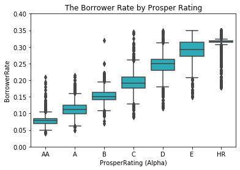

```python
# the fifth chart, ProsperRatings vs. BorrowerRate

ax4 = sb.boxplot(data = loan, x = 'ProsperRating (Alpha)',
                 y = 'BorrowerRate', color = base_color)
plt.ylim(0, 0.4)
plt.xlabel('ProsperRating (Alpha)')
plt.ylabel('BorrowerRate')
plt.title('The Borrower Rate by Prosper Rating')
```

> - The borrower rate shows a linear relationship to prosper rating. The deteorating prosper rating leads to rising borrower rate.

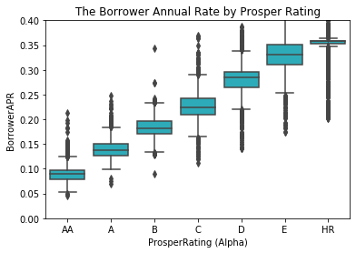

```python
# the sixth chart, ProsperRatings vs. BorrowerRateAPR

ax4 = sb.boxplot(data = loan, x = 'ProsperRating (Alpha)',
                 y = 'BorrowerAPR', color = base_color)
plt.ylim(0, 0.4)
plt.xlabel('ProsperRating (Alpha)')
plt.ylabel('BorrowerAPR')
plt.title('The Borrower Annual Rate by Prosper Rating')
```

> - The borrower annual rate also shows a strong linear correlation with prosper rating

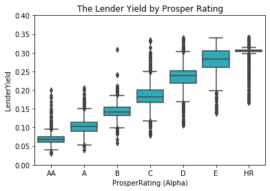

```python
# the seventh chart, ProsperRatings vs. LenderYield

ax4 = sb.boxplot(data = loan, x = 'ProsperRating (Alpha)',
                 y = 'LenderYield', color = base_color)
plt.ylim(0, 0.4)
plt.xlabel('ProsperRating (Alpha)')
plt.ylabel('LenderYield')
plt.title('The Lender Yield by Prosper Rating')
```

> - The lender yield also shows a strong correlation with prosper rating, the improving prosper rating decreases the lender yield.

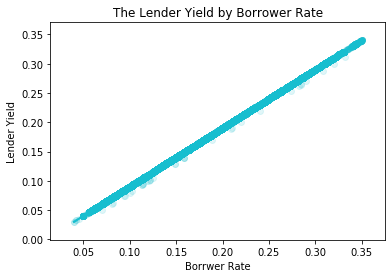

```python
ax6 = sb.regplot(data = loan, x = 'BorrowerRate',
                 y = 'LenderYield', color = base_color,
                 scatter_kws = {'alpha' : 1/8})

plt.xlabel('Borrwer Rate')
plt.ylabel('Lender Yield')
plt.title('The Lender Yield by Borrower Rate')
```

## Bivariate Analysis

### Discuss the distribution(s) of your variable(s) of interest. Were there any unusual points? Did you need to perform any transformations?

**The borrower rate histogram analysis**

> - The Borrower Rate histogram is highly correlated with the Prosper Rating. The decreasing prosper rate (which indicates the increasing risks) is correlated with an increasing borrower rate.
> - When colored with the income range, the peaks of the borrowers with higher incomes (USD50,000-74,999 and USD100k+) clearly shift towards left, indicating a lower borrwer rate (between 0.1 and 0.2). Interestingly, the borrowers with lower incomes(USD 2.5k to 4.9k) shift towards the right side, indicateing a higher borrower rate (0.2 to 0.35). There's a peak at 0.32 for most income ranges.
> - The plot also showed most the borrowers are employed.
> - Also, owning a home did help to decrease the borrowing rate for the given dataset.

**Does the Prosper Rating system favor the house owner?**

> - The plot shows owning a house did help the borrowers to get a better prosper rating scale. But for the borrowers with worse prosper rating scale, owning a house didn't help much.

**Heat map of Borrower rate vs. Loan amount**

> - The loan amount tend to fall on 4k, 10k, 15k, 20k, and 25k these five peaks.
> - On each specific loan amount peak, the borrower rate has a wide spread.
> - Specifically, at the 4k peak, more counts is obseved at higher borrower rate range (0.25 to 0.32).
> - On 10k, 15k, 20k, and 25k loan amount peaks, the borrower rate mainly aggregate from 0.1 to 0.25.
> - At higher loan amount 20k and 25k, the borrower rate shift towards the left compare to the lower loan amount 10k and 4k.

**Prosper ratings vs. Loan Amount**

*How the prosper rating system affect the amount of money the borrower can borrow?*

> - The plot shows the borrower has higher prosper rating scales D, E, and HR (high risk) obtain less amount of loan money.
> - **Unusual point explained:** The average amount of the loan money for E and HR borrowers is around 4k.
> - Since the borrower with high prosper rating scale indicate a high risk, it is reasonable that these borrowers (D, E, HR) will have more difficulties to borrow larger loan amounts on the Prosper platform.

**Prosper ratings vs. CreditScoreUpper**

> - The plot shows the ProsperRating system is generally consistent with the CreditScoreRangeUpper system becuase higher PropsperRating scale (low risk) is associate with higher CreditScoreRangeUpper Score.

**Prosper ratings vs. Debt to Income ratio**

> - The plot shows the debt to income ratio raises as the prosper rating decreases.

**Income range vs. Debt to Income ratio**

> - The plot shows as the income range increases, the debt to income ratio decreases.

**Prosper ratings vs. Borrower rate**

> - The borrower rate shows a linear relationship to prosper rating. The deteorating prosper rating leads to rising borrower rate.

**Prosper ratings vs. Lender yield**

> - The lender yield also shows a strong correlation with prosper rating, the improving prosper rating decreases the lender yield.

### Of the features you investigated, were there any unusual distributions? Did you perform any operations on the data to tidy, adjust, or change the form of the data? If so, why did you do this?

> - In the heat map of Borrower rate vs. Loan amount, the hottest spot showed at borrower rate 0.32 with loan amount 4k.

*The reasons of performing the above operations to the data are listed below.*

- The ProsperRating records did not exist prior to July 2009, it shows as missing data in the earlier records. Prior to 2009, the CreditGrade was used as the evaluation system by Prosper.
- Since we have more ProsperRating over CrediGrade records, the rows with the CrediGrade records will be excluded from this analysis.
- Based on the previous univariate analysis results, I decided to exclude the outliers and the rows which donot contain the necessary information for this analysis.

## Multivariate Analysis

- In this section I will continue to explore how effective the prosper rating system is to screen the borrowers and help the investors to avoid risk.
- What is the borrower's financial status under the debt and how the investors are affected.

```
 <a list of 4 Text xticklabel objects>)
```

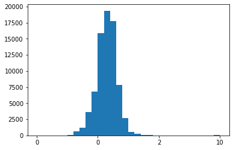

```python
# apply cuberoot transformation
def qrt_trans(x, inverse = False):
    """transformation helper function"""
    if not inverse:
        return x ** (1/4)
    else:
        return x ** 4

bin_edges = np.arange(0, qrt_trans(loan['DebtToIncomeRatio'].max())+0.06, 0.06);
plt.hist(loan6['DebtToIncomeRatio'].apply(qrt_trans), bins = bin_edges);
tick_locs = np.arange(0, qrt_trans(loan['DebtToIncomeRatio'].max())+0.6, 0.6)
plt.xticks(tick_locs, qrt_trans(tick_locs, inverse = True).astype(int))
```

```python
loan['DebtToIncomeRatio_qrt'] = loan['DebtToIncomeRatio'].apply(qrt_trans)
```

```python
print(qrt_trans(0.1))
print(qrt_trans(10))
```

```
0.5623413251903491
1.7782794100389228
```

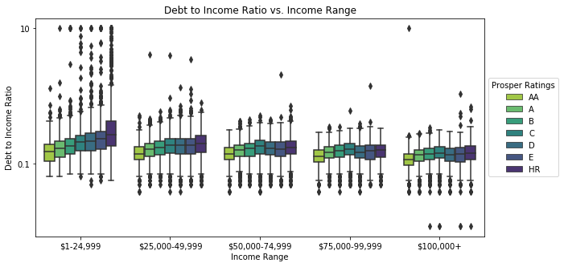

```python
# seaborn cluster boxplot will be applied
plt.figure(figsize = [10, 5])
sb.boxplot(data = loan, x = 'IncomeRange', y = 'DebtToIncomeRatio_qrt',
           hue = 'ProsperRating (Alpha)', palette = 'viridis_r')
#sb.regplot(data = loan, x = 'IncomeRange', y = 'DebtToIncomeRatio_qrt', scatter = False)

plt.legend(loc = 6, bbox_to_anchor = (1.0, 0.5), title = 'Prosper Ratings')

# set the y- axis ticks
plt.yticks([0.5623413251903491, 1.7782794100389228], ['0.1', '10']);

plt.xlabel('Income Range')
plt.ylabel('Debt to Income Ratio')
plt.title('Debt to Income Ratio vs. Income Range')
```

> - The plot shows within each income range, the improving prosper rating yields a droping of the debt to income ratio.
> - Besides, the raising income range also showed a droping trend of the debt to income ratio.
> - There are more outliers in the lower income ranges with extremely high debt to income ratio.

```python
(loan['Investors'].describe()) ** 1/2
```

```
count    42023.000000
mean        34.238381
std         47.785784
min          0.500000
25%          0.500000
50%         15.500000
75%         49.000000
max        594.500000
Name: Investors, dtype: float64
```

```
 <a list of 12 Text xticklabel objects>)
```

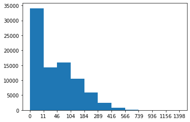

```python
# apply cuberoot transformation
def sqrt_trans(x, inverse = False):
    """transformation helper function"""
    if not inverse:
        return x ** (1/2)
    else:
        return x ** 2

bin_edges = np.arange(0, sqrt_trans(loan['Investors'].max())+3.4, 3.4);
plt.hist(loan['Investors'].apply(sqrt_trans), bins = bin_edges);
tick_locs = np.arange(0, sqrt_trans(loan['Investors'].max())+3.4, 3.4)
plt.xticks(tick_locs, sqrt_trans(tick_locs, inverse = True).astype(int))
```

```python
loan['Investors_sqrt'] = loan['Investors'].apply(sqrt_trans)
```

```python
loan['Investors_sqrt'].describe()
```

```
count    84046.000000
mean         6.326130
std          5.334527
min          1.000000
25%          1.000000
50%          5.567764
75%          9.899495
max         34.481879
Name: Investors_sqrt, dtype: float64
```

```python
print(sqrt_trans(1200))
print(sqrt_trans(500))
```

```
34.64101615137755
22.360679774997898
```

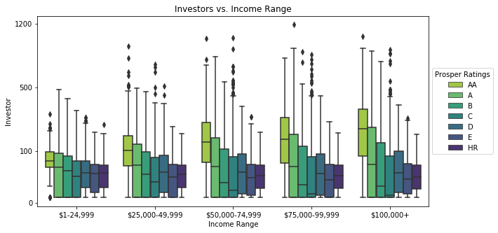

```python
# seaborn cluster boxplot will be applied
plt.figure(figsize = [10, 5])
sb.boxplot(data = loan, x = 'IncomeRange', y = 'Investors_sqrt',
           hue = 'ProsperRating (Alpha)', palette = 'viridis_r')
#sb.regplot(data = loan, x = 'IncomeRange', y = 'DebtToIncomeRatio_qrt', scatter = False)

plt.legend(loc = 6, bbox_to_anchor = (1.0, 0.5), title = 'Prosper Ratings')

# set the y- axis ticks
#plt.yticks([0.5623413251903491, 1.7782794100389228], ['0.1', '10']);
plt.yticks([0, 10, 22.360679774997898, 34.64101615137755], [0, 100, 500, 1200])
plt.xlabel('Income Range')
plt.ylabel('Investor')
plt.title('Investors vs. Income Range')
```

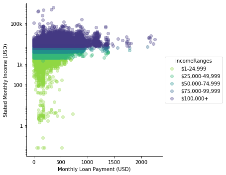

```python
g = sb.FacetGrid(data = loan, hue = 'IncomeRange', height = 5,
                 palette = 'viridis_r')
g.map(plt.scatter, 'MonthlyLoanPayment', 'StatedMonthlyIncome', alpha = 1/3)
plt.legend(['$1-24,999', '$25,000-49,999', '$50,000-74,999', '$75,000-99,999', '$100,000+'], title = 'IncomeRanges',
           loc = 6, bbox_to_anchor = (1.0, 0.5))
plt.yscale('log')
plt.ylim(0, 1000000)
plt.yticks([1, 100, 1000, 100000], ['1', '100', '1k', '100k']);
plt.xlabel('Monthly Loan Payment (USD)')
plt.ylabel('Stated Monthly Income (USD)')
```

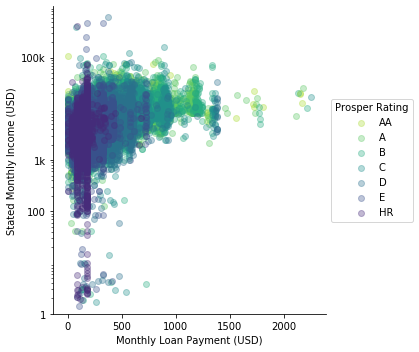

```python
g = sb.FacetGrid(data = loan, hue = 'ProsperRating (Alpha)', height = 5,
                 palette = 'viridis_r')
g.map(plt.scatter, 'MonthlyLoanPayment', 'StatedMonthlyIncome', alpha = 1/3)
plt.legend(title = 'Prosper Rating',
           loc = 6, bbox_to_anchor = (1.0, 0.5))
plt.yscale('log')
plt.ylim(0, 1000000)
plt.yticks([1, 100, 1000, 100000], ['1', '100', '1k', '100k']);
plt.xlabel('Monthly Loan Payment (USD)')
plt.ylabel('Stated Monthly Income (USD)')
```

> - The plot shows higher income allows the borrower to afford higher monthly loan payment.
> - The HR borrowers' monthly income varies from low to very high.
> - Monthly loan payment USD1.2k seems a threshold. There's a significant drop of the borrowers number willing to pay more than USD1.2k a month.

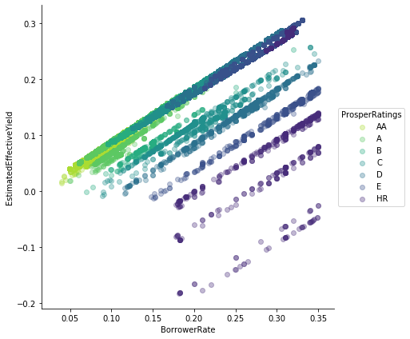

```python
# right one, scatter plot of the two numeric variables (borrowerRate EstimatedEffYield)
# plus the categorical variable ProsperRatings

g = sb.FacetGrid(data = loan, hue = 'ProsperRating (Alpha)', height = 6,
                 palette = 'viridis_r')
g.map(plt.scatter, 'BorrowerRate', 'EstimatedEffectiveYield', alpha = 1/3)
plt.legend(['AA', 'A', 'B', 'C', 'D', 'E', 'HR'], title = 'ProsperRatings',
           loc = 6, bbox_to_anchor = (1.0, 0.5))
```

```
(0, 0.21)
```

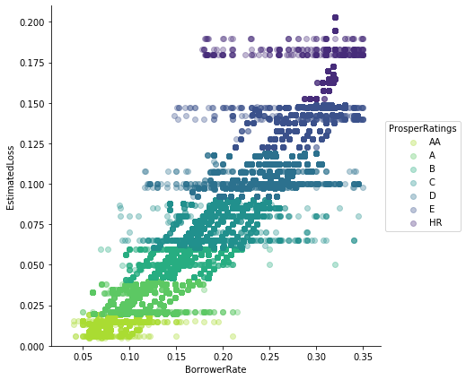

```python
# right one, scatter plot of the two numeric variables (borrowerRate EstimatedEffYield)
# plus the categorical variable ProsperRatings

g = sb.FacetGrid(data = loan, hue = 'ProsperRating (Alpha)', height = 6,
                 palette = 'viridis_r')
g.map(plt.scatter, 'BorrowerRate', 'EstimatedLoss', alpha = 1/3)
plt.legend(['AA', 'A', 'B', 'C', 'D', 'E', 'HR'], title = 'ProsperRatings',
           loc = 6, bbox_to_anchor = (1.0, 0.5))
plt.ylim(0, 0.21)
```

> - The plot shows the improving prosper rating lower the borrow rate, it reduces the estimated loss as well.

```
(0, 0.21)
```

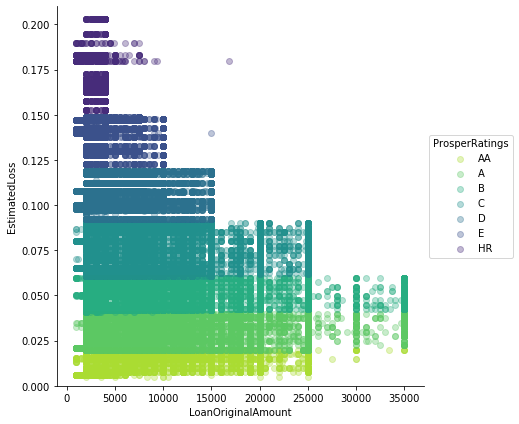

```python
# right one, scatter plot of the two numeric variables (borrowerRate EstimatedEffYield)
# plus the categorical variable ProsperRatings

g = sb.FacetGrid(data = loan, hue = 'ProsperRating (Alpha)', height = 6,
                 palette = 'viridis_r')
g.map(plt.scatter, 'LoanOriginalAmount', 'EstimatedLoss', alpha = 1/3)
plt.legend(['AA', 'A', 'B', 'C', 'D', 'E', 'HR'], title = 'ProsperRatings',
           loc = 6, bbox_to_anchor = (1.0, 0.5))
plt.ylim(0, 0.21)
```

### Is the prosper rating system able to differentiate the borrower's debt pressure?

*We can explore that question through plot the relationships between the real monthly income, loan original amount, and prosper ratings*

### How the prosper rating system affect the investors?

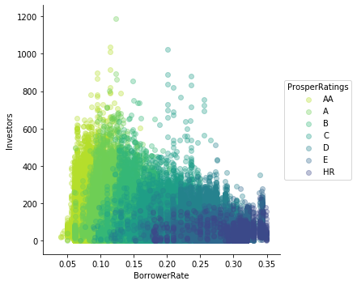

```python
# two categorical variables plus one numeric variables. Use seaborn FacetScatter plot
g = sb.FacetGrid(data = loan6, hue = 'ProsperRating (Alpha)', height = 5,
                 palette = 'viridis_r')
g.map(plt.scatter, 'BorrowerRate', 'Investors', alpha = 1/3)
plt.legend(['AA', 'A', 'B', 'C', 'D', 'E', 'HR'], title = 'ProsperRatings',
           loc = 6, bbox_to_anchor = (1.0, 0.5))
```

> - The plot shows a borrower with better prosper ratings has more investors and lower borrower rate.
> - The plot also indicates the investors in general prefer to invest the borrowers with lower risk, even it means sacrifice with lower borrower rate.

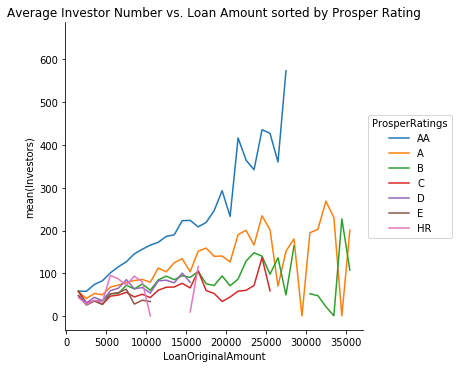

```python
def mean_poly(x, y, bins = bin_edges, **kwargs):
    """Custom adapted line plot code."""
    # set bin edges if non or int specified
    if type(bins) == int:
        bins = np.linspace(x.min(), x.max(), bins+1)
    bin_centers = (bin_edges[1:] + bin_edges[:-1]) / 2

    # compute counts
    data_bins = pd.cut(x, bins, right = False,
                       include_lowest = True)
    means = y.groupby(data_bins).mean()

    # create plot
    plt.errorbar(x = bin_centers, y = means, **kwargs)

bin_edges = np.arange(999, loan['LoanOriginalAmount'].max()+1000, 1000)
g = sb.FacetGrid(data = loan, hue = 'ProsperRating (Alpha)', height = 5)
g.map(mean_poly, 'LoanOriginalAmount', 'Investors', bins = bin_edges)
g.set_ylabels('mean(Investors)')
plt.legend(['AA', 'A', 'B', 'C', 'D', 'E', 'HR'], title = 'ProsperRatings',
           loc = 6, bbox_to_anchor = (1.0, 0.5))
plt.title('Average Investor Number vs. Loan Amount sorted by Prosper Rating')
```

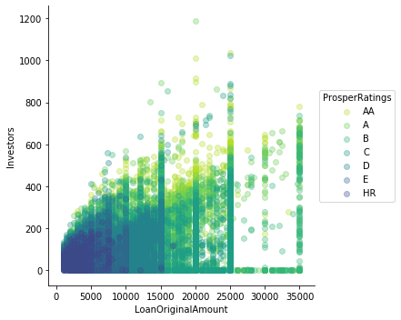

```python
g = sb.FacetGrid(data = loan6, hue = 'ProsperRating (Alpha)', height = 5,
                 palette = 'viridis_r')
g.map(plt.scatter, 'LoanOriginalAmount', 'Investors', alpha = 1/3)
plt.legend(['AA', 'A', 'B', 'C', 'D', 'E', 'HR'], title = 'ProsperRatings',
           loc = 6, bbox_to_anchor = (1.0, 0.5))
```

```
(0, 1600)
```

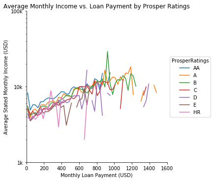

```python
def mean_poly(x, y, bins = bin_edges, **kwargs):
    """Custom adapted line plot code."""
    # set bin edges if non or int specified
    if type(bins) == int:
        bins = np.linspace(x.min(), x.max(), bins+1)
    bin_centers = (bin_edges[1:] + bin_edges[:-1]) / 2

    # compute counts
    data_bins = pd.cut(x, bins, right = False,
                       include_lowest = True)
    means = y.groupby(data_bins).mean()

    # create plot
    plt.errorbar(x = bin_centers, y = means, **kwargs)

bin_edges = np.arange(0, loan['MonthlyLoanPayment'].max()+29.3, 29.3)
g = sb.FacetGrid(data = loan, hue = 'ProsperRating (Alpha)', height = 5)
g.map(mean_poly, 'MonthlyLoanPayment', 'StatedMonthlyIncome', bins = bin_edges)
g.set_ylabels('mean(Investors)')
plt.legend(['AA', 'A', 'B', 'C', 'D', 'E', 'HR'], title = 'ProsperRatings',
           loc = 6, bbox_to_anchor = (1.0, 0.5))
plt.title('Average Investor Number vs. Loan Amount sorted by Prosper Rating')
plt.yscale('log')
plt.yticks([1000, 10000, 100000], ['1k', '10k', '100k']);
plt.xlabel('Monthly Loan Payment (USD)')
plt.ylabel('Average Stated Monthly Income (USD)')
plt.title('Average Monthly Income vs. Loan Payment by Prosper Ratings');
plt.ylim(1000, 100000)
plt.xlim(0, 1600)
```

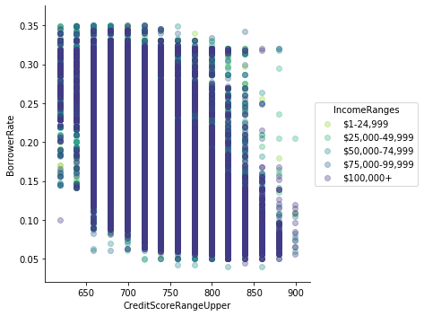

```python
g = sb.FacetGrid(data = loan6, hue = 'IncomeRange', height = 5,
                 palette = 'viridis_r')
g.map(plt.scatter, 'CreditScoreRangeUpper', 'BorrowerRate', alpha = 1/3)
plt.legend(['$1-24,999', '$25,000-49,999', '$50,000-74,999', '$75,000-99,999', '$100,000+'], title = 'IncomeRanges',
           loc = 6, bbox_to_anchor = (1.0, 0.5))
#plt.yscale('log')
#plt.ylim(0, 1000000)
#plt.yticks([1, 1000, 100000], ['1', '1k', '100k']);
```

## Multivariate Analysis

### Discuss the distribution(s) of your variable(s) of interest. Were there any unusual points? Did you need to perform any transformations?

**Debt to income ratio vs. income ranges by prosper rating system**

> - The plot shows within each income range, the improving prosper rating yields a droping of the debt to income ratio.
> - Besides, the rising income range also showed a droping trend of the debt to income ratio.
> - There are more outliers in the lower income ranges with extremely high debt to income ratio.

**Monthly loan payment vs. stated monthly income by income ranges**

> - The plot shows higher income allows the borrower to afford higher monthly loan payment.

**Investors vs. income ranges vs. prosper ratings**

> - With in each income range, the borrower with better prosper rating receives more investors.
> - The borrower with higher income also attracts more investors.

**Monthly loan payment vs. stated monthly income vs. income ranges**

> - Borrower with higher income can afford higher monthly loan payment

**Monthly loan payment vs. stated monthly income vs. prosper ratings**

> - The plot shows higher income allows the borrower to afford higher monthly loan payment.
> - The HR borrowers' monthly income varies from low to very high.
> - Monthly loan payment USD1.2k seems a threshold. There's a significant drop of the borrowers number willing to pay more than USD1.2k a month.

**Borrower rate vs. estimated effective yield vs. prosper rating**

> - The plot shows at the same borrower rate (like 0.2, 0.25), the estimated yield is below zero for HR (high risk borrower) but positive for AA, A and B (low risk borrowers).
> - The plot also reflects although the higher risk scale on the prosper ratings brings higher borrower rate, but due to the increased risk, the estimated yield may get compromised as well.

**Borrower rate vs. estimated loss vs. prosper rating**

> - The plot shows the improving prosper rating lower the borrow rate, it reduces the estimated loss as well.

**Loan amount vs. estimated loss vs. prosper rating**

> - The plot shows improving prosper rating increases the chance of borrow larger amount of money.
> - The improving prosper rating also brings down the estimated loss.
> - The borrower with prosper rating HR can only obtain around USD4000 loan according to the plot.
> - Which further explained the odd highest 4k peak (among the other 10k, 15k, 20k peaks) observed in the LoanOriginalAmount histogram plot in the first section.

**Borrower rate vs. investors vs prosper rating**

> - The plot shows a borrower with better prosper ratings has more investors and lower borrower rate.
> - The plot also indicates the investors in general prefer to invest the borrowers with lower risk, even it means sacrifice with lower borrower rate.

**Loan amount vs. investors vs prosper rating**

> - The plot indicates the investor tends to invest less money to the borrowers with high risk on the prosper rating system.
> - Specifically, the HR borrower receives the least amount of loan money from the investors, with around USD4k, which is consistent with previous findings.
> - Interestingly, this plot also shows a large number of B and C borrowers receive large amount of loan (USD25k and 35k) from lots of investors.
> - Since the previous plot reveals that the B and C borrowers have a higher borrower rate compare to the AA and A borrowers, the pattern observed here indicates a certain number of investors willing to take a greater risk for a higher borrower rate in pursuing a higher return.

### Of the features you investigated, were there any unusual distributions? Did you perform any operations on the data to tidy, adjust, or change the form of the data? If so, why did you do this?

*I performed the 4-cuberoot, cuberoot, and logarithmic transformation on the y- axis scale of the charts in this section. Because the oridinary linear scatter of the dots cannot present the features of the targeted data. To full expose the data features, I applied the above mentioned transformations.